# Course Project

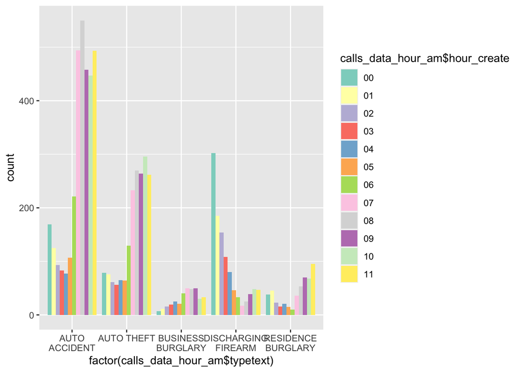

```r
ggplot(calls_data_hour_am, aes(factor(calls_data_hour_am$typetext),fill = calls_data_hour_am$hour_create)) +
geom_bar(stat="count", position = "dodge") + scale_x_discrete(labels = function(x) stringr::str_wrap(x, width = 10)) + scale_fill_brewer(palette="Set3")
```

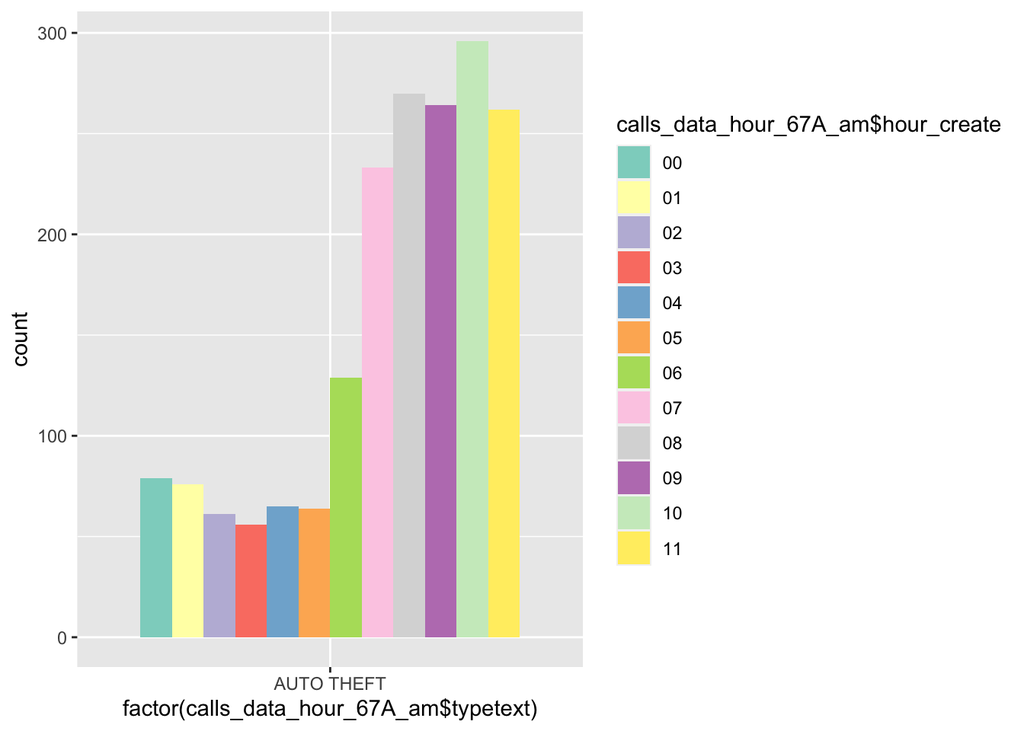

```r
calls_data_hour_67A_am = filter(calls_data_hour_am, type == '67A')
ggplot(calls_data_hour_67A_am, aes(factor(calls_data_hour_67A_am$typetext),fill = calls_data_hour_67A_am$hour_create)) +
geom_bar(stat="count", position = "dodge") + scale_x_discrete(labels = function(x) stringr::str_wrap(x, width = 12)) + scale_fill_brewer(palette = "Set3")
```

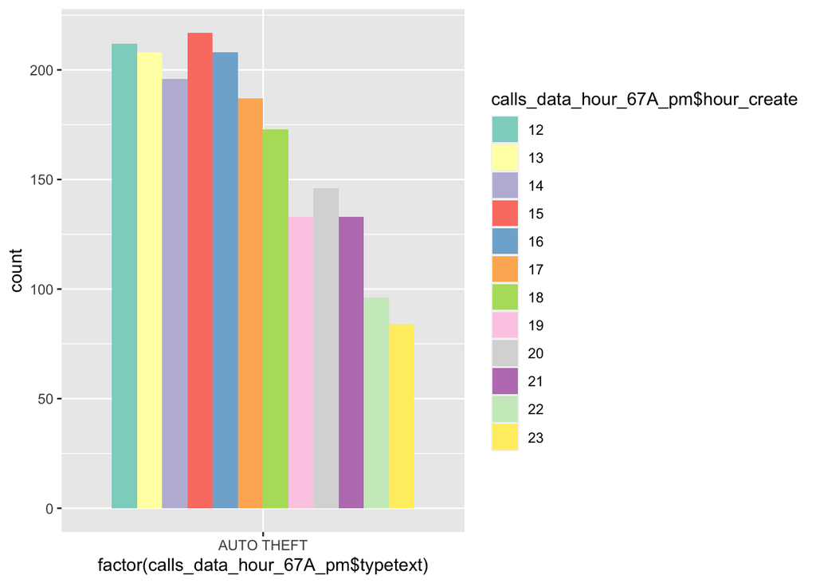

```r
calls_data_hour_67A_pm = filter(calls_data_hour_pm, type == '67A')
ggplot(calls_data_hour_67A_pm, aes(factor(calls_data_hour_67A_pm$typetext),fill = calls_data_hour_67A_pm$hour_create)) +
geom_bar(stat="count", position = "dodge") +
scale_fill_brewer(palette = "Set3") + scale_x_discrete(labels = function(x) stringr::str_wrap(x, width = 12))
```

##auto theft calls are most common at 10am and 3pm

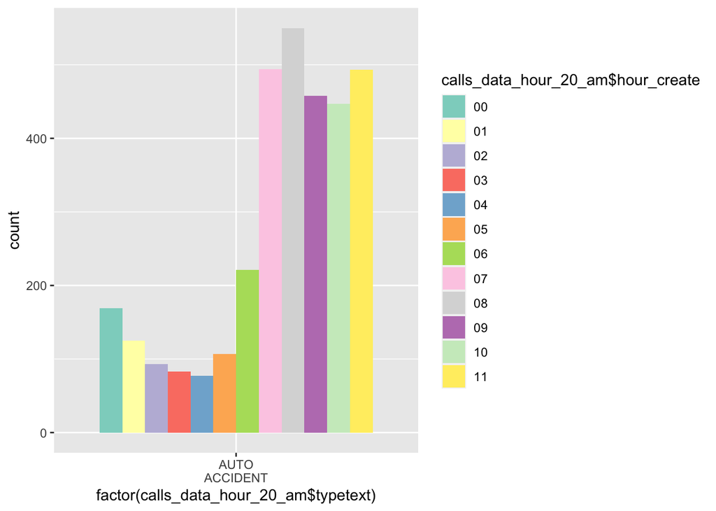

```r
calls_data_hour_20_am = filter(calls_data_hour_am, type == '20')
ggplot(calls_data_hour_20_am, aes(factor(calls_data_hour_20_am$typetext),fill = calls_data_hour_20_am$hour_create)) +
geom_bar(stat="count", position = "dodge") + scale_x_discrete(labels = function(x) stringr::str_wrap(x, width = 12)) + scale_fill_brewer(palette = "Set3")
```

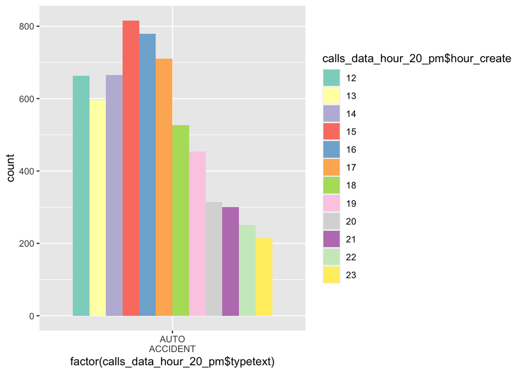

```r
calls_data_hour_20_pm = filter(calls_data_hour_pm, type == '20')
ggplot(calls_data_hour_20_pm, aes(factor(calls_data_hour_20_pm$typetext),fill = calls_data_hour_20_pm$hour_create)) +
geom_bar(stat="count", position = "dodge") +
scale_fill_brewer(palette = "Set3") + scale_x_discrete(labels = function(x) stringr::str_wrap(x, width = 12))
```

##auto accident calls are most common at 8am and 3pm

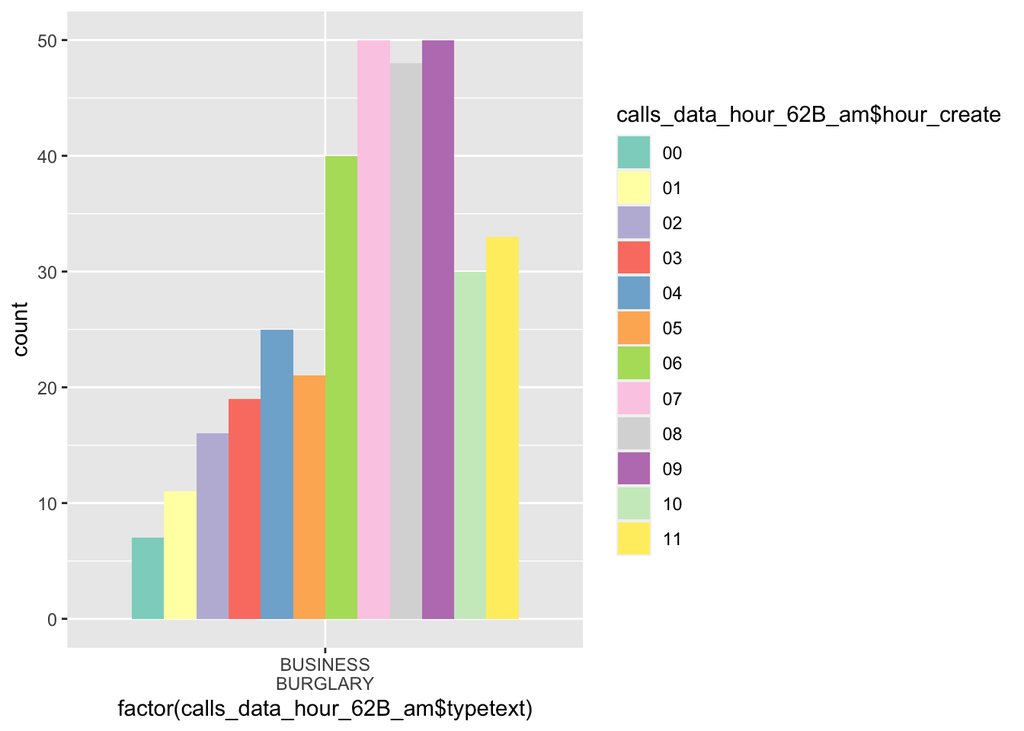

```r
calls_data_hour_62B_am = filter(calls_data_hour_am, type == '62B')
ggplot(calls_data_hour_62B_am, aes(factor(calls_data_hour_62B_am$typetext),fill = calls_data_hour_62B_am$hour_create)) +
geom_bar(stat="count", position = "dodge") + scale_x_discrete(labels = function(x) stringr::str_wrap(x, width = 12)) + scale_fill_brewer(palette = "Set3")
```

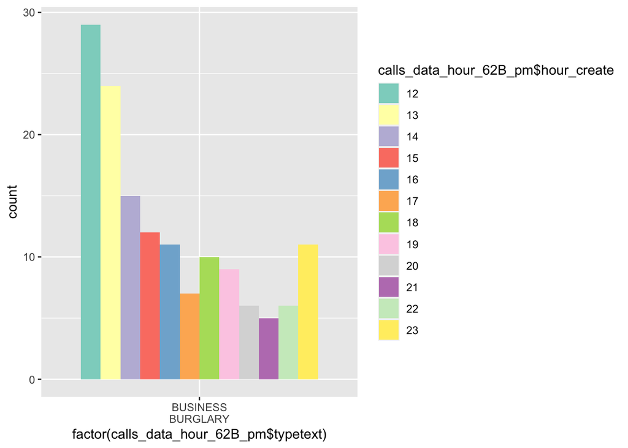

```r
calls_data_hour_62B_pm = filter(calls_data_hour_pm, type == '62B')
ggplot(calls_data_hour_62B_pm, aes(factor(calls_data_hour_62B_pm$typetext),fill = calls_data_hour_62B_pm$hour_create)) +
geom_bar(stat="count", position = "dodge") +
scale_fill_brewer(palette = "Set3") + scale_x_discrete(labels = function(x) stringr::str_wrap(x, width = 12))
```

##business burglary calls are most common at 7am and 9 am and 12 pm

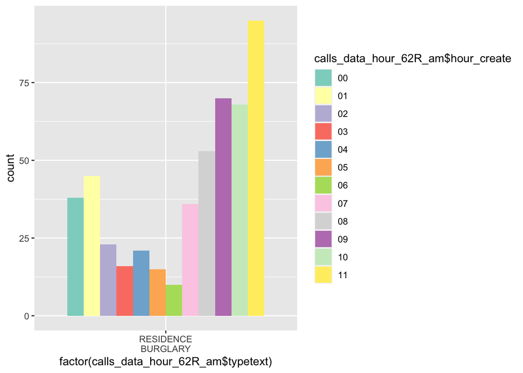

```r
calls_data_hour_62R_am = filter(calls_data_hour_am, type == '62R')
ggplot(calls_data_hour_62R_am, aes(factor(calls_data_hour_62R_am$typetext),fill = calls_data_hour_62R_am$hour_create)) +
geom_bar(stat="count", position = "dodge") + scale_x_discrete(labels = function(x) stringr::str_wrap(x, width = 12)) + scale_fill_brewer(palette = "Set3")
```

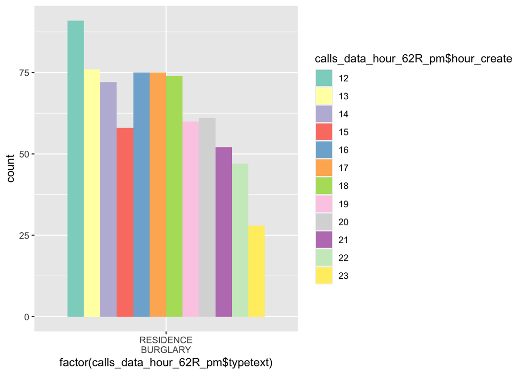

```r
calls_data_hour_62R_pm = filter(calls_data_hour_pm, type == '62R')
ggplot(calls_data_hour_62R_pm, aes(factor(calls_data_hour_62R_pm$typetext),fill = calls_data_hour_62R_pm$hour_create)) +
geom_bar(stat="count", position = "dodge") +
scale_fill_brewer(palette = "Set3") + scale_x_discrete(labels = function(x) stringr::str_wrap(x, width = 12))
```

##resident burglary calls are most common at 11am and 12pm

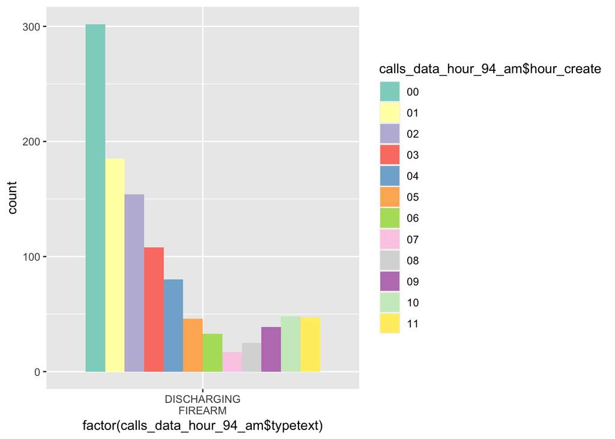

```r
calls_data_hour_94_am = filter(calls_data_hour_am, type == '94')
ggplot(calls_data_hour_94_am, aes(factor(calls_data_hour_94_am$typetext),fill = calls_data_hour_94_am$hour_create)) +
geom_bar(stat="count", position = "dodge") + scale_x_discrete(labels = function(x) stringr::str_wrap(x, width = 12)) + scale_fill_brewer(palette = "Set3")
```

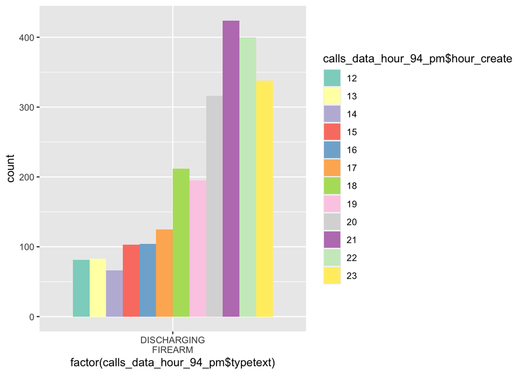

```r
calls_data_hour_94_pm = filter(calls_data_hour_pm, type == '94')
ggplot(calls_data_hour_94_pm, aes(factor(calls_data_hour_94_pm$typetext),fill = calls_data_hour_94_pm$hour_create)) +
geom_bar(stat="count", position = "dodge") +
scale_fill_brewer(palette = "Set3") + scale_x_discrete(labels = function(x) stringr::str_wrap(x, width = 12))
```

##calls about discharging firearms are recieved mostly at 9pm and midnight